# MetricGraph: Random Fields on Metric Graphs

David Bolin, Alexandre B. Simas, and Jonas Wallin

Created: 2022-11-26. Last modified: 2024-05-08.

# 1 Introduction

There has lately been much interest in statistical modeling of data on compact metric graphs such as street or river networks based on Gaussian random fields.

The `R` package `MetricGraph` contains functions for working with data and random fields on compact metric graphs. The main functionality is contained in the `metric_graph` class, which is used for specifying metric graphs, adding data to them, visualization, and other basic functions that are needed for working with data and random fields on metric graphs. The package also implements three types of Gaussian processes on metric graphs: The Whittle–Matérn fields introduced by [Bolin, Simas, and Wallin (2024)](https://arxiv.org/abs/2205.06163) and [Bolin, Simas, and Wallin (2023)](https://arxiv.org/abs/2304.10372), Gaussian processes with isotropic covariance functions [Anderes, Møller, and Rasmussen (2020)](https://projecteuclid.org/journals/annals-of-statistics/volume-48/issue-4/Isotropic-covariance-functions-on-graphs-and-their-edges/10.1214/19-AOS1896.full), and Gaussian models based on the graph Laplacian [Borovitskiy et al. (2021)](http://proceedings.mlr.press/v130/borovitskiy21a/borovitskiy21a.pdf).

Basic statistical tasks such as likelihood evaluation and prediction is implemented for these three types of models in `MetricGraph`. Further, the package also contains interfaces to `R-INLA` [Lindgren and Rue (2015)](https://www.jstatsoft.org/article/view/v063i19), package available from [http://R-INLA. org/download/](https://www.r-inla.org/) and `inlabru` [Bachl et al. (2019)](https://besjournals.onlinelibrary.wiley.com/doi/10.1111/2041-210X.13168) that facilitates using those packages for full Bayesian inference of general Latent Gaussian Models (LGMs) that includes Whittle–Matérn fields on metric graphs.

The package is available to install via the repository https://github.com/davidbolin/MetricGraph.

# 2 The `metric_graph` class

A compact metric graph $\Gamma$ consists of a set of finitely many vertices $\mathcal{V}=\{v_i\}$ and a finite set $\mathcal{E}=\{e_j\}$ of edges connecting the vertices. Each edge $e$ is defined by a pair of vertices $(v_i,v_k)$ and a finite length $l_e \in (0,\infty)$. An edge in the graph is a curve parametrized by arc-length, and a location $s\in \Gamma$ is a position on an edge, and can thus be represented as a touple $(e,t)$ where $t\in[0,l_e]$.

## 2.1 Basic constructions

A metric graph is represented in the `MetricGraph` package through the class `metric_graph`. An object of this class can be constructed in two ways. The first is to specify the vertex matrix `V` and the edge matrix `E`, and it is then assumed that all edges are straight lines. The second, more flexible, option is to specify the object from a `SpatialLines` object using the `sp` package (Bivand, Pebesma, and Gomez-Rubio 2013).

To illustrate this, we use the `osmdata` package to download data from OpenStreetMap. In the following code, we extract the streets on the campus of King Abdullah University of Science and Technology (KAUST) as a `SpatialLines` object:

```r
call <- opq(bbox = c(39.0884, 22.33, 39.115, 22.3056))
call <- add_osm_feature(call, key = "highway",value=c("motorway",
                                                      "primary","secondary",
                                                      "tertiary",
                                                      "residential"))
data <- osmdata_sp(call)
lines <- SpatialLines(data$osm_lines@lines)
```

We can now create the metric graph as follows. In the command we set the argument `longlat = TRUE` since the coordinates of the vertices are given in Longitude and Latitude.

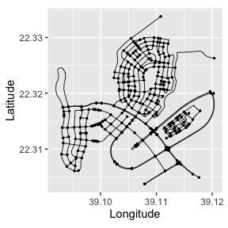

```r
graph <- metric_graph$new(lines, longlat = TRUE)
graph$plot(vertex_size = 0.5)
```

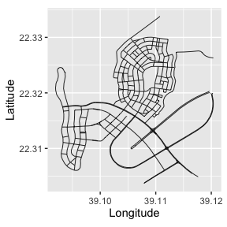

```r
graphs <- graph_components$new(edges = lines, longlat = TRUE)
graph <- graphs$get_largest()
graph$plot(vertex_size = 0)
```

The `graph` object now contains all important features of the graph, such as the vertex matrix `graph$V`, the number of vertices `graph$nV`, the edge matrix `graph$E`, the number of edges `graph$nE`, and the vector of all edge lengths `graph$get_edge_lengths()` given in the unit km (since we specified `longlat = TRUE` in the construction). Thus, we can obtain the range of the edge lengths in the unit m as:

```r
range(graph$get_edge_lengths(unit="m"))
```

```
## Units: [m]
## [1]    5.650044 2141.415006
```

We will also remove the vertices of degree 2 by using the `prune_vertices()` method:

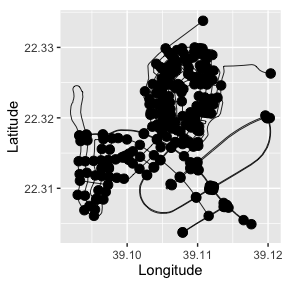

```r
graph$prune_vertices()
graph$plot()
```

## 2.2 Understanding coordinates on graphs

The locations of the vertices are specified in Euclidean coordinates. However, when specifying a position on the graph, it is not practical to work with Euclidean coordinates since not all locations in Euclidean space are locations on the graph. It is instead better to specify a location on the graph by the touple $(i, t)$, where $i$ denotes the number of the edge and $t$ is the location on the edge. The location $t$ can either be specified as the distance from the start of the edge (and then takes values between 0 and the length of the edge) or as the normalized distance from the start of the edge (and then takes values between 0 and 1). The function `coordinates` can be used to convert between coordinates in Euclidean space and locations on the graph. For example the location at normalized distance 0.2 from the start of the second edge is:

```r
graph$coordinates(PtE = matrix(c(2, 0.2), 1,2), normalized = TRUE)
```

```
##          [,1]     [,2]
## [1,] 39.11751 22.31934
```

The function can also be used to find the closest location on the graph for a location in Euclidean space:

```r
graph$coordinates(XY = matrix(c(39.117, 22.319), 1,2))
```

```
##      [,1]      [,2]
## [1,]    2 0.2517662
```

In this case, the `normalized` argument decides whether the returned value should be given in normalized distance or not.

## 2.3 Adding data to the graph

Given that we have constructed the metric graph, we can now add data to it. For further details on data manipulation on metric graphs, see Data manipulation on metric graphs. As an example, let us sample some locations on edges at random and add data to them in the graph:

```r
n.obs <- 10
data <- data.frame(edge_number = sample(1:graph$nE, n.obs),
                   distance_on_edge = runif(n.obs),
                   y = rnorm(n.obs))
graph$add_observations(data = data, normalized = TRUE)
```

```
## Adding observations...
```

```
## The unit for edge lengths is km
```

```
## The current tolerance for removing distant observations is (in km): 1.07070750299905
```

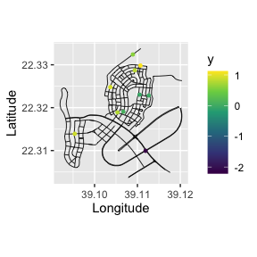

```r
graph$plot(data = "y", vertex_size = 0)
```

One should note here that one needs to specify `normalized = TRUE` in the function to specify that the locations are in normalized distance on the edges. If this command is not set, the distances are interpreted as not being normalized. The `add_observations()` function accepts multiple types of inputs. One scenario that can be common in applications is to have the data as `SpatialPoints` objects, and one can then add the observations as a `SpatialPointsDataFrame`. To illustrate this, let us again sample some locations at random on the graph, then use the function `coordinates` to transform those to Longitude Latitude coordinates, which we then use to create a `SpatialPointsDataFrame` object which we add to the graph:

```r
obs.loc <- cbind(sample(1:graph$nE, n.obs), runif(n.obs))
obs.lonlat <- graph$coordinates(PtE = obs.loc, normalized = TRUE)
obs <- rnorm(n.obs)
points <- SpatialPointsDataFrame(coords = obs.lonlat,
                                 data = data.frame(y = obs))
graph$add_observations(points)
```

```
## Adding observations...
```

```
## The unit for edge lengths is km
```

```
## The current tolerance for removing distant observations is (in km): 1.07070750299905
```

```
## Converting data to PtE
```

```
## This step may take long. If this step is taking too long consider pruning the vertices to possibly obtain some speed up.
```

```
## [1] y        .coord_x .coord_y
## <0 linhas> (ou row.names de comprimento 0)
```

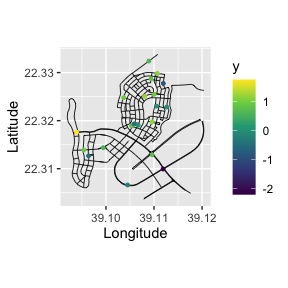

```r
graph$plot(data = "y", vertex_size = 0)
```

If we want to replace the data in the object, we can use `clear_observations()` to remove all current data.

## 2.4 Working with functions on metric graphs

When working with data on metric graphs, one often wants to display functions on the graph. The best way to visualize functions on the graph is to evaluate them on a fine mesh over the graph and then use `plot_function`. To illustrate this procedure, let us construct a mesh on the graph:

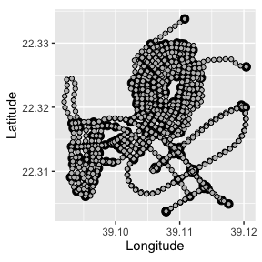

```r
graph$build_mesh(h = 100/1000)
graph$plot(mesh=TRUE)
```

In the command `build_mesh`, the argument `h` decides the largest spacing between nodes in the mesh. Above we chose that as 100m which is a bit coarse. So let us reduce the value of `h` to 10m and rebuild the mesh:

```r
  graph$build_mesh(h = 10/1000)
```

Suppose now that we want to display the function $f(s) = \text{Longitude}(s) - \text{Latitude}(s)$ on this graph. We then first evaluate it on the vertices of the mesh and then use the function `plot_function` to display it:

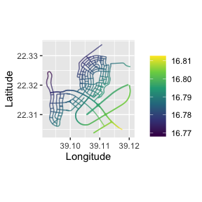

```r
lon <- graph$mesh$V[, 1]
lat <- graph$mesh$V[, 2]
f <- lon - lat
graph$plot_function(X = f, vertex_size = 0, edge_width = 0.5)
```

Alternatively, we can set `plotly = TRUE` in the plot command to get a 3D visualization of the function by using the `plotly` (Sievert 2020) package. When the first argument of `plot_function` is a vector, the function assumes that the values in the vector are the values of the function evaluated at the vertices of the mesh. As an alternative, one can also provide the first argument as a matrix consisting of the triplets $(i, t, f(i, t))$, where $i$ denotes the edge number, $t$ the location on the edge, and $f(i, t)$ the value at that point.

# 3 Random fields on metric graphs

Having defined the metric graph, we are now ready to specify Gaussian processes on it. In this section, we will briefly cover the three main types of Gaussian processes that are supported. Be begin by the main class of models, the Whittle–Matérn fields, then consider Gaussian processes with isotropic covariance functions, and finally look at discrete models based on the graph Laplacian.

## 3.1 Whittle–Matérn fields

The Gaussian Whittle–Matérn fields are specified as solutions to the stochastic differential equation
$$(\kappa^2 - \Delta)^{\alpha/2} \tau u = \mathcal{W}$$
on the metric graph $\Gamma$. We can work with these models without and approximations if the smoothness parameter $\alpha$ is an integer, and this is what we focus on in this vignette. For details on the case of a general smoothness parameter, see Whittle–Matérn fields with general smoothness.

### 3.1.1 Sampling

As an example, let us simulate the field $u$ on the graph using $\alpha = 1$. To do so, we again draw some locations at random, then sample the field at these locations and plot the result

```r
sigma <- 1.3
range <- 0.15 # range parameter
sigma_e <- 0.1

n.obs <- 200
obs.loc <- cbind(sample(1:graph$nE, n.obs, replace=TRUE), runif(n.obs))

u <- sample_spde(range = range, sigma = sigma, alpha = 1,
                 graph = graph, PtE = obs.loc)
graph$clear_observations()
graph$add_observations(data = data.frame(edge_number = obs.loc[, 1],
                                         distance_on_edge = obs.loc[, 2],
                                         u = u),
                       normalized = TRUE)
```

```
## Adding observations...
```

```
## The unit for edge lengths is km
```

```
## The current tolerance for removing distant observations is (in km): 1.07070750299905
```

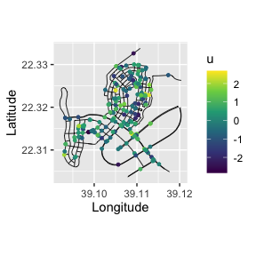

```r
graph$plot(data = "u", vertex_size = 0)
```

We can also sample the field at the mesh on the graph as follows:

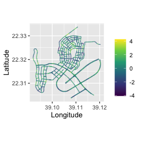

```r
u <- sample_spde(range = range, sigma = sigma, alpha = 1,
                 graph = graph, type = "mesh")
graph$plot_function(X = u, vertex_size = 0, edge_width = 0.5)
```

Since $\alpha=1$, these sample paths are continuous but not differentiable. To visualize the correlation structure of the field, we can compute and plot the covariances between some point and all other points in the graph as follows:

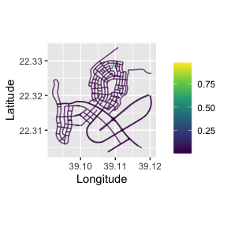

```r
C <- spde_covariance(c(200, 0.1), range = range, sigma = sigma, alpha = 1,
                            graph = graph)
graph$plot_function(X = C, vertex_size = 0, edge_width = 0.5)
```

To obtain a field with differentiable sample paths, we can change to $\alpha=2$ in the code above.

### 3.1.2 Inference

In the following examples we will consider models without replicates. Please, see the Gaussian random fields on metric graphs vignette for examples with replicates.

Suppose that we have data of the form
$$y_i = \beta_1\text{lon}(s_i) + \beta_1\text{lat}(s_i) + u(s_i) +
\varepsilon_i, \quad i=1,\ldots,n$$
where $s_i\in \Gamma$ are observation locations, lon and lat are the longitude and latitude of these locations, $\beta_1,\beta_2$ are some regression coefficients, and $\varepsilon_i$ are independent centered Gaussian variables $N(0,\sigma_e^2)$ representing measurement noise.

Let us create such observations, clear the current data in the graph, and finally add the data on the graph:

```
## Adding observations...
```

```
## The unit for edge lengths is km
```

```
## The current tolerance for removing distant observations is (in km): 1.07070750299905
```

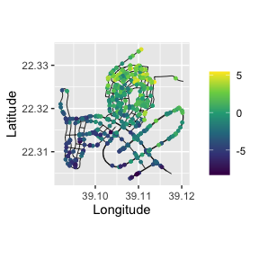

```r
sigma <- 2
range <- 0.2 # range parameter
sigma_e <- 0.1

n.obs.1 <- 400 # all edges
n.obs.2 <- 100 # long edges

n.obs <- n.obs.1 + n.obs.2

obs.loc <- cbind(sample(1:graph$nE, n.obs.1, replace=TRUE), runif(n.obs.1))

# Let us now add some locations on long edges:
long.edges <- graph$edge_lengths > 0.5

obs.loc <- rbind(obs.loc, cbind(sample(which(long.edges), n.obs.2, replace=TRUE), runif(n.obs.2)))

u <- sample_spde(range = range, sigma = sigma, alpha = 1,
                 graph = graph, PtE = obs.loc)

beta0 = -1
beta1 = 1
beta2 = 2
lonlat <- graph$coordinates(PtE = obs.loc)
scaled_lonlat <- scale(lonlat)
y <- beta0 + beta1 * scaled_lonlat[, 1] + beta2 * scaled_lonlat[, 2] + u + sigma_e*rnorm(n.obs)

data <- data.frame(edge_number = obs.loc[, 1],
                   distance_on_edge = obs.loc[, 2],
                   lon = scaled_lonlat[, 1],
                   lat = scaled_lonlat[, 2],
                   y = y)

graph$clear_observations()
graph$plot(X = y, X_loc = obs.loc, vertex_size = 0)
graph$add_observations(data = data, normalized = TRUE)
```

Our goal now is to fit a linear mixed-effects model on this data assuming a Whittle-Mat'ern latent model with $\alpha=1$. To this end, we can use the `graph_lme()` function.

If we do not specify the model, it will fit a linear regression model. So, let us first fit a simple linear regression model to illustrate:

```r
res_lm <- graph_lme(y ~ lon + lat, graph = graph)
```

We can get the summary:

```r
summary(res_lm)
```

```
##
## Linear regression model
##
## Call:
## graph_lme(formula = y ~ lon + lat, graph = graph)
##
## Fixed effects:
##             Estimate Std. Error t value Pr(>|t|)
## (Intercept) -1.13093    0.06936  -16.31   <2e-16 ***
## lon          0.93551    0.07075   13.22   <2e-16 ***
## lat          2.04390    0.07075   28.89   <2e-16 ***
```

```
##
## No random effects.
```

```
##
## Measurement error:
## std. dev
## 1.550846
## ---
## Signif. codes:  0 '***' 0.001 '**' 0.01 '*' 0.05 '.' 0.1 ' ' 1
##
## Log-Likelihood:  -927.3651
```

```r
res <- graph_lme(y ~ lon + lat, graph = graph, model = 'WM1')
```

Let us get the summary of the result:

```r
summary(res)
```

```
##
## Latent model - Whittle-Matern with alpha = 1
##
## Call:
## graph_lme(formula = y ~ lon + lat, graph = graph, model = "WM1")
##
## Fixed effects:
##             Estimate Std.error z-value Pr(>|z|)
## (Intercept)  -1.1014    0.1181  -9.324  < 2e-16 ***
## lon           0.9511    0.1201   7.922 2.34e-15 ***
## lat           1.9748    0.1232  16.035  < 2e-16 ***
##
## Random effects:
##        Estimate Std.error z-value
## tau    0.114099  0.005449  20.941
## kappa 11.506072  1.742238   6.604
##
## Random effects (Matern parameterization):
##       Estimate Std.error z-value
## sigma  1.82701   0.09598  19.036
## range  0.17382   0.02583   6.729
##
## Measurement error:
##          Estimate Std.error z-value
## std. dev  0.07595   0.04519   1.681
## ---
## Signif. codes:  0 '***' 0.001 '**' 0.01 '*' 0.05 '.' 0.1 ' ' 1
##
## Log-Likelihood:  -794.3335
## Number of function calls by 'optim' = 26
## Optimization method used in 'optim' = L-BFGS-B
##
## Time used to:     fit the model =  11.76227 secs
```

We can obtain additional information by using `glance()`:

```r
glance(res)
```

```
## # A tibble: 1 × 9
##    nobs  sigma logLik   AIC   BIC deviance df.residual model         alpha
##   <int>  <dbl>  <dbl> <dbl> <dbl>    <dbl>       <dbl> <chr>         <dbl>
## 1   500 0.0760  -794. 1601. 1626.    1589.         494 WhittleMatern     1
```

We will now compare with the true values of the random effects:

```r
sigma_e_est <- res$coeff$measurement_error[[1]]
sigma_est <- res$matern_coeff$random_effects[1]
range_est <- res$matern_coeff$random_effects[2]
results <- data.frame(sigma_e = c(sigma_e, sigma_e_est),
                      sigma = c(sigma, sigma_est),
                      range = c(range, range_est),
                      row.names = c("Truth", "Estimate"))
print(results)
```

```
##             sigma_e   sigma     range
## Truth    0.10000000 2.00000 0.2000000
## Estimate 0.07595015 1.82701 0.1738213
```

Now, we can compute the predictions for $y$. First, let us compute the posterior mean for the field at the observation locations and plot the residuals between the posterior means and the field:

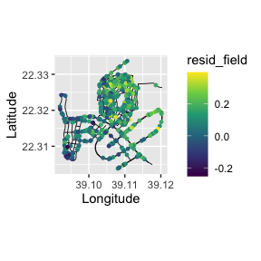

```r
pred_u <- predict(res, newdata = data, normalized = TRUE)
pred_u$resid_field <- pred_u$re_mean - u
pred_u <- graph$process_data(data = pred_u, normalized=TRUE)
pred_u %>% graph$plot(data = "resid_field", vertex_size = 0)
```

We can also obtain predictions by using the `augment()` function:

Let us first plot the predictions for the field, then the fitted values:

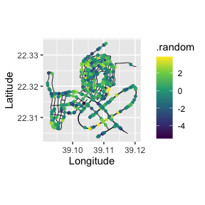

```r
pred_aug <- augment(res, newdata = data, normalized = TRUE)

pred_aug %>% graph$plot(data = ".random", vertex_size = 0)
```

Let us now plot the fitted values along with the observed values:

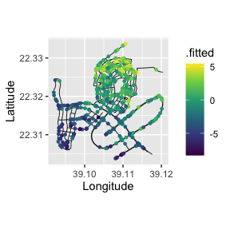

```r
pred_aug %>% graph$plot(data = ".fitted", vertex_size = 0)
```

Let us now obtain predictions of the field on a mesh of equally spaced nodes on the graph. First, let us create the mesh and `data.frame`:

```r
graph$build_mesh(h = 50/1000)
lonlat_mesh <- graph$coordinates(PtE = graph$mesh$VtE)
scaled_lonlat_mesh <- scale(lonlat_mesh,
                            center = attr(scaled_lonlat, "scaled:center"),
                            attr(scaled_lonlat, "scaled:scale"))
data_mesh_pred <- data.frame(lon = scaled_lonlat_mesh[,1],
                              lat = scaled_lonlat_mesh[,2],
                              edge_number = graph$mesh$VtE[,1],
                              distance_on_edge = graph$mesh$VtE[,2])
# Let us remove duplicated vertices (that were created due to being too close)
data_mesh_pred <- data_mesh_pred[!duplicated(graph$mesh$V),]
```

Now, let us obtain the predictions. We can obtain estimates for the latent field by taking the `re_mean` element from the `pred` list obtained by calling `prediction()`:

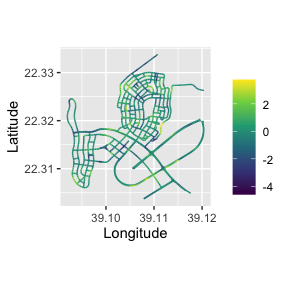

```r
pred <- predict(res, newdata=data_mesh_pred, normalized=TRUE)
u_est <- pred$re_mean
graph$plot_function(X = u_est, vertex_size = 0, edge_width = 0.5)
```

Finally, let us obtain predictions for the observed values on the mesh. In this case we use the `mean` component of the `pred` list:

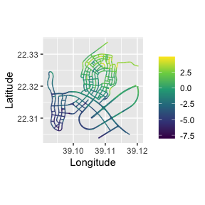

```r
y_est <- pred$mean
graph$plot_function(X = y_est, vertex_size = 0, edge_width = 0.5)
```

The same procedure can be done with $\alpha = 2$. One can also estimate $\alpha$ from data as described in the vignette Whittle–Matérn fields with general smoothness.

## 3.2 Isotropic Gaussian fields

For metric graphs with Euclidean edges, [Anderes, Møller, and Rasmussen (2020)](https://projecteuclid.org/journals/annals-of-statistics/volume-48/issue-4/Isotropic-covariance-functions-on-graphs-and-their-edges/10.1214/19-AOS1896.full) showed that one can define valid Gaussian processes through various isotropic covariance functions if the distances between points are measured in the so-called resistance metric $d(\cdot,\cdot)$. One example of a valid covariance function is the isotropic exponential covariance function
$$r(d(s,t)) = \sigma^2\exp(-\kappa d(s,t)).$$
This covariance is very similar to that of the Whittle–Mat'ern fields with $\alpha = 1$. Between the two, we recommend using the Whittle–Matérn model since it has Markov properties which makes inference much faster. Further, that covariance is well-defined for any compact metric graph, whereas the isotropic exponential is only guaranteed to be positive definite if the graph has Euclidean edges. See [Bolin, Simas, and Wallin (2023)](https://arxiv.org/abs/2304.10372) for further comparisons.

However, let us now illustrate how to use it for the data that we generated above. To work with the covariance function, the only cumbersome thing is to compute the metric. The `metric_graph` class has built in support for this, and we can obtain the distances between the observation locations as

```r
graph$compute_resdist()
```

However, if the goal is to fit a model using this covariance function, there is no need for the user to compute it. It is done internally when one uses the `graph_lme()` function. We need to set the `model` argument in `graph_lme()` as a list with type `"isoCov"` (there is no need to add additional arguments, as the exponential covariance is the default). Let us fit a linear regression model with a random effect given by a Gaussian field with an isotropic exponential covariance function (alternatively, one can also write `model = 'isoExp'`):

```r
res_exp <- graph_lme(y ~ lon + lat, graph = graph, model = list(type = "isoCov"))
```

```
## Warning in graph_lme(y ~ lon + lat, graph = graph, model = list(type = "isoCov")): No check for Euclidean edges have been perfomed on this graph. The isotropic covariance models are only known to work
## for graphs with Euclidean edges. You can check if the graph has Euclidean edges by running the `check_euclidean()` method. See the vignette
## https://davidbolin.github.io/MetricGraph/articles/isotropic_noneuclidean.html for further details.
```

Observe that we received a warning saying that we did not check if the graph has Euclidean edges. This is due to the fact that the isotropic covariance models are only known to work for graphs with Euclidean edges. Let us check if the graph has Euclidean edges. To this end, we need to use the `check_euclidean()` method:

```r
graph$check_euclidean()
```

Now, we simply call the graph to print its characteristics to check the information:

```r
graph
```

```
## A metric graph with  248  vertices and  397  edges.
##
## Vertices:
##   Degree 1: 12;  Degree 2: 1;  Degree 3: 164;  Degree 4: 67;  Degree 5: 4;
##   With incompatible directions:  1
##
## Edges:
##   Lengths:
##       Min: 0.005650044  ; Max: 2.141415  ; Total: 64.48864
##   Weights:
##       Min: 1  ; Max: 1
##   That are circles:  0
##
## Graph units:
##   Vertices unit:  degrees  ; Lengths unit:  km
##
## Longitude and Latitude coordinates:  TRUE
##   Which spatial package:  sp
##   CRS:  +proj=longlat +datum=WGS84 +no_defs
##
## Some characteristics of the graph:
##   Connected: TRUE
##   Has loops: FALSE
##   Has multiple edges: TRUE
##   Is a tree: FALSE
##   Distance consistent: unknown
```

```
## To check if the graph satisfies the distance consistency, run the `check_distance_consistency()` method.
```

```
##   Has Euclidean edges: FALSE
```

Observe that this graph DOES NOT have Euclidean edges. This means that the model with isotropic exponential covariance is not guaranteed to work for this graph. In any case, we can try to fit it anyway. Observe that we will now receive a different warning, since now we know for fact that the graph does not have Euclidean edges. In this case, we will set `model` to `isoexp` for conveniency.

```r
res_exp <- graph_lme(y ~ lon + lat, graph = graph, model = "isoexp")
```

```
## Warning in graph_lme(y ~ lon + lat, graph = graph, model = "isoexp"): This graph DOES NOT have Euclidean edges. The isotropic covariance models are NOT guaranteed to work for this graph! See the
## vignette https://davidbolin.github.io/MetricGraph/articles/isotropic_noneuclidean.html for further details.
```

```r
summary(res_exp)
```

```
##
## Latent model - Covariance-based model
##
## Call:
## graph_lme(formula = y ~ lon + lat, graph = graph, model = "isoexp")
##
## Fixed effects:
##             Estimate Std.error z-value Pr(>|z|)
## (Intercept)  -1.1399    0.1846  -6.175 6.61e-10 ***
## lon           0.9183    0.1423   6.454 1.09e-10 ***
## lat           2.0044    0.1644  12.194  < 2e-16 ***
##
## Random effects:
##       Estimate Std.error z-value
## tau    1.71966   0.09721  17.690
## kappa 14.04626   2.41997   5.804
##
## Measurement error:
##          Estimate Std.error z-value
## std. dev  0.06769   0.04953   1.367
## ---
## Signif. codes:  0 '***' 0.001 '**' 0.01 '*' 0.05 '.' 0.1 ' ' 1
##
## Log-Likelihood:  -801.5418
## Number of function calls by 'optim' = 40
## Optimization method used in 'optim' = L-BFGS-B
##
## Time used to:     fit the model =  22.40233 secs
```

We can also have a glance at the fitted model:

```r
glance(res_exp)
```

```
## # A tibble: 1 × 9
##    nobs  sigma logLik   AIC   BIC deviance df.residual model  cov_function
##   <int>  <dbl>  <dbl> <dbl> <dbl>    <dbl>       <dbl> <chr>  <chr>
## 1   500 0.0677  -802. 1615. 1640.    1603.         494 isoCov exp_covariance
```

Let us now compute the posterior mean for the field at the observation locations and plot the residuals between the field and the posterior means of the field:

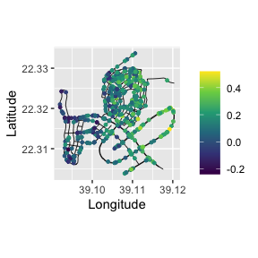

```r
pred_exp <- predict(res_exp, newdata = data, normalized = TRUE)
graph$plot(X = pred_exp$re_mean - u, X_loc = data[,1:2], vertex_size = 0)
```

To perform kriging prediction to other locations, one can use the `predict()` method along with a `data.frame` containing the locations in which one wants to obtain predictions and the corresponding covariate values at these locations. In this example we will use the `data_mesh_pred` from the previous example. Let us estimate the observed values at the mesh locations:

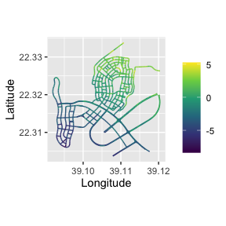

```r
pred_exp_y <- predict(res_exp, newdata = data_mesh_pred,
                    normalized=TRUE)
y_est_exp <- pred_exp_y$mean
graph$plot_function(X = y_est_exp, vertex_size = 0, edge_width = 0.5)
```

## 3.3 Models based on the Graph Laplacian

A final set of Gaussian models that is supported by `MetricGraph` is the Matérn type processes based on the graph Laplacian introduced by [Borovitskiy et al. (2021)](http://proceedings.mlr.press/v130/borovitskiy21a/borovitskiy21a.pdf). These are multivariate Gaussian distributions, which are defined in the vertices through the equation
$$(\kappa^2\mathbf{I} - \mathbf{\Delta}_\Gamma)^{\alpha/2}\mathbf{u} =
\mathbf{W}$$
Here $\mathbf{W}\sim N(0,\sigma^2\mathbf{I})$ is a vector with independent Gaussian variables and $\mathbf{\Delta}_\Gamma$ is the graph Laplacian. Further, $\mathbf{u}$ is a vector with the values of the process in the vertices of $\Gamma$, which by definition has precision matrix
$$\mathbf{Q} = \sigma^{-2}(\kappa^2\mathbf{I} -
\mathbf{\Delta}_\Gamma)^{\alpha}$$
Thus, to define these models, the only “difficult” thing is to compute the graph Laplacian. The (weighted) graph Laplacian, where the weights are specified by the edge lengths can be computed by the function `compute_laplacian()` in the `metric_graph` object. Suppose that we want to fit the data that we defined above with this model. We can use the `graph_lme()` function. Also, observe that there is no need to use the `compute_laplacian()` function, as it is done internally. We now set the `model` argument as a list with the `type` being `"GraphLaplacian"` (alternatively, one can also write `model = 'GL1'`) to obtain a graph Laplacian model with `alpha=1`:

```r
res_gl <- graph_lme(y ~ lon + lat, graph = graph, model = list(type = "GraphLaplacian"),
                            optim_method = "Nelder-Mead")
summary(res_gl)
```

```
##
## Latent model - graph Laplacian SPDE with alpha = 1
##
## Call:
## graph_lme(formula = y ~ lon + lat, graph = graph, model = list(type = "GraphLaplacian"),
##     optim_method = "Nelder-Mead")
##
## Fixed effects:
##             Estimate Std.error z-value Pr(>|z|)
## (Intercept)  -1.1225    0.1145  -9.801  < 2e-16 ***
## lon           0.9618    0.1199   8.024 1.02e-15 ***
## lat           2.0373    0.1179  17.277  < 2e-16 ***
##
## Random effects:
##       Estimate Std.error z-value
## tau   0.109437  0.006147  17.803
## kappa 2.993409  0.383903   7.797
##
## Random effects (Matern parameterization):
##       Estimate Std.error z-value
## sigma  3.73454   0.14569  25.633
## range  0.66813   0.07945   8.409
##
## Measurement error:
##          Estimate Std.error z-value
## std. dev  0.05041   0.08726   0.578
## ---
## Signif. codes:  0 '***' 0.001 '**' 0.01 '*' 0.05 '.' 0.1 ' ' 1
##
## Log-Likelihood:  -792.0891
## Number of function calls by 'optim' = 491
## Optimization method used in 'optim' = Nelder-Mead
##
## Time used to:     fit the model =  1.34554 secs
```

We can also have a glance at the fitted model:

```r
glance(res_gl)
```

```
## # A tibble: 1 × 9
##    nobs  sigma logLik   AIC   BIC deviance df.residual model          alpha
##   <int>  <dbl>  <dbl> <dbl> <dbl>    <dbl>       <dbl> <chr>          <dbl>
## 1   500 0.0504  -792. 1596. 1621.    1584.         494 GraphLaplacian     1
```

We can now obtain prediction at the observed locations by using the `predict()` method. Let us compute the posterior mean for the field at the observation locations and plot the residuals between the field and the posterior means of the field:

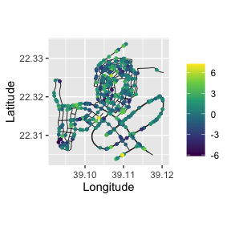

```r
pred_GL <- predict(res_gl, newdata = data, normalized = TRUE)
graph$plot(X = pred_GL$re_mean - u, X_loc = data[,1:2], vertex_size = 0)
```

Now, if we do predictions outside of the observation locations on a graph Laplacian model, we need to modify the graph. This modifies the model in its entirety. Thus, we need to refit the model with all the observation locations we want to do predictions. However, if we use the `predict()` method with observations outside of the observation locations, the `predict()` will return predictions together with a `warning` that one should refit the model to obtain proper predictions. Here, we will see the (incorrect way of obtaining) predictions of the observed data:

```r
pred_GL_y <- predict(res_gl, newdata = data_mesh_pred,
                    normalized=TRUE)
```

```
## Warning in predict.graph_lme(res_gl, newdata = data_mesh_pred, normalized = TRUE): There are prediction locations outside of the observation locations. Refit the model with all the locations you want
## to obtain predictions.
```

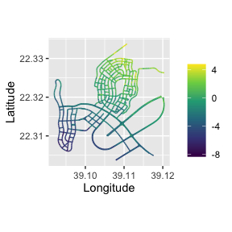

```r
y_est_GL <- pred_GL_y$mean
graph$plot_function(X = y_est_GL, vertex_size = 0, edge_width = 0.5)
```

Let us now refit the model with all the locations we want to obtain predictions. Let us create a new data set with all the original locations and all the locations we want to obtain predictions (with `y=NA` at the locations we want to obtain predictions):

```r
data_mesh_temp <- data_mesh_pred
data_mesh_temp[["y"]] <- rep(NA, nrow(data_mesh_pred))

new_data <- merge(data, data_mesh_temp, all = TRUE)
```

Let us clone the graph and add the new data:

```r
graph_pred <- graph$clone()
graph_pred$clear_observations()
graph_pred$add_observations(data = new_data, normalized = TRUE)
```

```
## Adding observations...
```

```
## The unit for edge lengths is km
```

```
## The current tolerance for removing distant observations is (in km): 1.07070750299905
```

Let us now fit the model with all data:

```r
res_gl_pred <- graph_lme(y ~ lon + lat, graph = graph_pred, model = list(type = "GraphLaplacian"),
                                optim_method = "Nelder-Mead")
summary(res_gl_pred)
```

```
##
## Latent model - graph Laplacian SPDE with alpha = 1
##
## Call:
## graph_lme(formula = y ~ lon + lat, graph = graph_pred, model = list(type = "GraphLaplacian"),
##     optim_method = "Nelder-Mead")
##
## Fixed effects:
##             Estimate Std.error z-value Pr(>|z|)
## (Intercept) -1.11486   0.09908  -11.25   <2e-16 ***
## lon          0.92625   0.08130   11.39   <2e-16 ***
## lat          2.07185   0.08080   25.64   <2e-16 ***
##
## Random effects:
##       Estimate Std.error z-value
## tau    0.16682   0.02479   6.730
## kappa  1.74728   0.42127   4.148
##
## Random effects (Matern parameterization):
##       Estimate Std.error z-value
## sigma   3.2066    0.1942  16.512
## range   1.1446    0.2376   4.817
##
## Measurement error:
##          Estimate Std.error z-value
## std. dev   0.9317    0.1017   9.162
## ---
## Signif. codes:  0 '***' 0.001 '**' 0.01 '*' 0.05 '.' 0.1 ' ' 1
##
## Log-Likelihood:  -896.1099
## Number of function calls by 'optim' = 501
## Optimization method used in 'optim' = Nelder-Mead
##
## Time used to:     fit the model =  2.88238 secs
```

One should compare the estimates with the ones obtained in the model without the prediction locations.

Let us first compute the residual between the latent field and the posterior means at the observation locations:

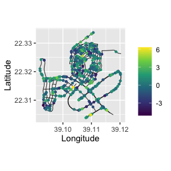

```r
pred_GL_full <- predict(res_gl_pred, newdata = data, normalized = TRUE)
graph$plot(X = pred_GL_full$re_mean - u, X_loc = data[,1:2], vertex_size = 0)
```

Let us now obtain predictions at the desired locations (in the correct way) of the observed data:

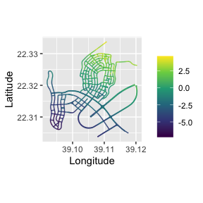

```r
pred_GL_y_full <- predict(res_gl_pred, newdata = data_mesh_pred,
                    normalized=TRUE)
y_est_GL_full <- pred_GL_y_full$mean
graph$plot_function(X = y_est_GL_full, vertex_size = 0, edge_width = 0.5)
```

# 4 The `inlabru` interface

In this vignette we will present our `inlabru` interface to Whittle–Matérn fields. The `MetricGraph` package also has a similar interface to`R-INLA`, which is described in detail in the INLA interface of Whittle–Matérn fields vignette.

## 4.1 Basic setup and estimation

We will use the same graph and data as before. The `inlabru` implementation requires the observation locations to be added to the graph. However, note that for the Whittle–Matérn fields (contrary to the models based on the graph Laplacian) we are not changing the model by adding vertices at observation locations. We already created the extended graph above, so we can use that. Now, we load `INLA` and `inlabru` packages. We will also need to create the `inla` model object with the `graph_spde` function. By default we have `alpha=1`.

```r
library(INLA)
library(inlabru)
spde_model <- graph_spde(graph)
```

Recall that the data is already on the graph object (from the previous models above). Now, we create `inlabru`’s component, which is a formula-like object:

```r
cmp <- y ~ Intercept(1) + lon + lat + field(loc, model = spde_model)
```

```r
spde_bru_fit <- bru(cmp, data =
              graph_data_spde(spde_model, loc_name = "loc")[["data"]])
```

The advantage / difference between the estimates we obtain here and those above is that the `bru` function does full Bayesian inference (assuming priors for the model parameters). We used the default priors when creating the `graph_spde` model (see the help text for that function). The advantage now is that we do not only obtain point estimates but entire posterior distributions for the parameters. To view the estimates we can use the `spde_metric_graph_result()` function, then taking a `summary()`:

```r
spde_bru_result <- spde_metric_graph_result(spde_bru_fit,
                    "field", spde_model)

summary(spde_bru_result)
```

```
##           mean        sd 0.025quant 0.5quant 0.975quant     mode
## sigma 1.878870 0.1058060   1.666470 1.861940   2.077830 1.856550
## range 0.179203 0.0269994   0.132426 0.177022   0.238259 0.172403
```

Here we are showing the estimate of the practical correlation range ($2/\kappa$) instead of $\kappa$ since that is easier to interpret. We now compare the means of the estimated values with the true values:

```r
  result_df_bru <- data.frame(
    parameter = c("std.dev", "range"),
    true = c(sigma, range),
    mean = c(
      spde_bru_result$summary.sigma$mean,
      spde_bru_result$summary.range$mean
    ),
    mode = c(
      spde_bru_result$summary.sigma$mode,
      spde_bru_result$summary.range$mode
    )
  )
  print(result_df_bru)
```

```
##   parameter true      mean      mode
## 1   std.dev  2.0 1.8788705 1.8565532
## 2     range  0.2 0.1792027 0.1724034
```

We can also plot the posterior marginal densities with the help of the `gg_df()` function:

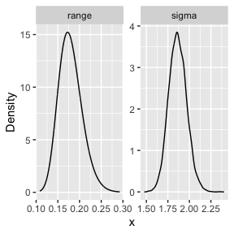

```r
  posterior_df_bru_fit <- gg_df(spde_bru_result)

  library(ggplot2)

  ggplot(posterior_df_bru_fit) + geom_line(aes(x = x, y = y)) +
  facet_wrap(~parameter, scales = "free") + labs(y = "Density")
```

## 4.2 Kriging with the `inlabru` implementation

Unfortunately, our `inlabru` implementation is not compatible with `inlabru`’s `predict()` method. This has to do with the nature of the metric graph’s object.

To this end, we have provided a different `predict()` method. We will now show how to do kriging with the help of this function.

We begin by creating a data list with the positions we want the predictions. In this case, we will want the predictions on a mesh.

The positions we want are the mesh positions, which we have in the `data.frame` for the previous models. The function `graph_bru_process_data()` helps us into converting that `data.frame` to an `inlabru` friendly format for dealing with metric graphs:

```r
data_list <- graph_bru_process_data(data_mesh_pred, loc = "loc")
```

We can now obtain the predictions by using the `predict()` method. Observe that our `predict()` method for graph models is a bit different from `inlabru`’s standard `predict()` method. Indeed, the first argument is the model created with the `graph_spde()` function, the second is `inlabru`’s component, and the remaining is as done with the standard `predict()` method in `inlabru`.

```r
field_pred <- predict(spde_model,
                                cmp,
                                spde_bru_fit,
                                newdata = data_list,
                                formula = ~ field)
```

Let us plot the predictions of the latent field:

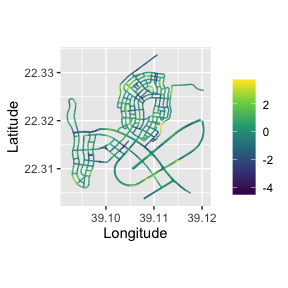

```r
mean_field_prd <- field_pred$pred[,1]
graph$plot_function(X = mean_field_prd, improve_plot = TRUE,
                      vertex_size = 0, edge_width = 0.5)
```

Finally, let us plot predictions of the observed data at the mesh locations:

```r
obs_pred <- predict(spde_model,
                                cmp,
                                spde_bru_fit,
                                newdata = data_list,
                                formula = ~ Intercept + lat + lon + field)
```

Let us plot the predictions:

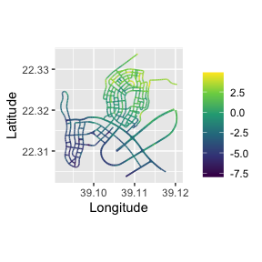

```r
mean_obs_prd <- obs_pred$pred[,1]
graph$plot_function(X = mean_obs_prd, improve_plot = TRUE,
                    vertex_size = 0, edge_width = 0.5)
```

# References

Anderes, Ethan, Jesper Møller, and Jakob G Rasmussen. 2020. “Isotropic Covariance Functions on Graphs and Their Edges.” *Annals of Statistics*.

Bachl, Fabian E., Finn Lindgren, David L. Borchers, and Janine B. Illian. 2019. “Inlabru an R Package for Bayesian Spatial Modelling from Ecological Survey Data.” *Methods in Ecology and Evolution*.

Bivand, Roger S., Edzer Pebesma, and Virgilio Gomez-Rubio. 2013. *Applied Spatial Data Analysis with R*. Springer, NY.

Bolin, David, Alexandre B. Simas, and Jonas Wallin. 2023. “Statistical Properties of Gaussian Whittle–Matérn Fields on Metric Graphs.” *arXiv:2304.10372*.

———. 2024. “Gaussian Whittle–Matérn Fields on Metric Graphs.” *Bernoulli*.

Borovitskiy, Viacheslav, Iskander Azangulov, Alexander Terenin, Peter Mostowsky, Marc Deisenroth, and Nicolas Durrande. 2021. “Matérn Gaussian Processes on Graphs.” *International Conference on Artificial Intelligence and Statistics*.

Lindgren, Finn, and Haavard Rue. 2015. “Bayesian Spatial Modelling with R-INLA.” *Journal of Statistical Software*.

Sievert, Carson. 2020. *Interactive Web-Based Data Visualization with R, Plotly, and Shiny*. Chapman and Hall/CRC.